# Experience

This experience shows an approach used to perform Time-Series data analysis involving Machine Learning for a MSc Thesis project called 'Observing and Controlling Performance in Microservices'.

### Context:

For this experience, there are values stored in a Time-Series database to be analysed. This values represent metrics extracted from a span data produced by a certain system.

### Objective:

The objective resides in answer the question related to anomaly detection: "Is there any faulty service?". To do this we use three questions:

1. Does any service present a significant change in the number of incoming requests?
2. Does any service present a significant change in the number of outgoing requests?
3. Does any service present a significant change in the response time?

### Features involved:

- Call count [IN] -- (Question 1);
- Call count [OUT] -- (Question 2);
- Response time -- (Question 3);

### Considerations:

- Multiple features to be analyzed;
- Possible correlation between features;
- Unlabeled data --> (Un)supervised learning;

```python
import pandas as pd
```

The code bellow was extracted from a module, opentsdb client, presented in Graphy. This function retrieves data from OpenTSDB using the REST API defined by the database developers. To retrieve data, the metric name, start timestamp and end timestamp must be provided.

```python
import requests
import json

opentsdb_address = 'http://127.0.0.1:4242/'
api_query = 'api/query'

def get_metrics(name: str, start_timestamp: int, end_timestamp: int) -> dict:
    """
    Gets the metrics from OpenTSDB.

    :param name: The name of the metrics.
    :param start_timestamp: The start unix timestamp of the metric.
    :param end_timestamp: The end unix timestamp of the metric.
    :return: The metrics as a dictionary if success, None otherwise.
    """
    json_body = {
        "start": start_timestamp,
        "end": end_timestamp,
        "queries": [{"aggregator": "sum", "metric": name},
                    {"aggregator": "sum", "tsuids": ["000001000002000042", "000001000002000043"]}]
    }

    data = None
    try:
        response = requests.post(opentsdb_address + api_query, data=json.dumps(json_body),
                                 headers={'content-type': 'application/json'})
        if response.status_code == 200:
            response_text = json.loads(response.text)
            if response_text:
                data = response_text[0].get('dps', None)
        return data
    except ConnectionError as ex:
        logger.error('{}: {}'.format(type(ex), ex))
        sys.exit(status=1)
```

# Data to be analyzed

The data is gathered from a Time-Series database (OpenTSDB). In this case we get some metrics from this kind of database to perform the analysis.

We are using the OUTER JOIN method to merge data from multiple features. This merge method preserves the data points and fills the missing values with NaN (Missing values).

```python
start_timestamp = 1530057600
end_timestamp = 1530316800

service_name = 'nova-api-cascading'

metric_name = 'huawei.call_count_in.{}'.format(service_name)
metric_name_2 = 'huawei.call_count_out.{}'.format(service_name)
metric_name_3 = 'huawei.response_time_avg.{}'.format(service_name)

metrics = get_metrics(metric_name, start_timestamp, end_timestamp)
metrics_2 = get_metrics(metric_name_2, start_timestamp, end_timestamp)
metrics_3 = get_metrics(metric_name_3, start_timestamp, end_timestamp)

# print(len(metrics.items()))
# print(len(metrics_2.items()))
# print(len(metrics_3.items()))

df_1 = pd.DataFrame(metrics.items(), columns=['time', 'call_count_in'])
df_2 = pd.DataFrame(metrics_2.items(), columns=['time', 'call_count_out'])
df_3 = pd.DataFrame(metrics_3.items(), columns=['time', 'response_time_avg'])

df = pd.merge(df_1, df_2, how='outer')
df = pd.merge(df, df_3, how='outer')

print('\nData info:\n{}'.format(df.info()))

print('\nData:\n{}'.format(df))

print('\nMissing values counting:\n{}'.format(df.isna().sum()))
```

```
<class 'pandas.core.frame.DataFrame'>
Int64Index: 690 entries, 0 to 689
Data columns (total 4 columns):
time                 690 non-null object
call_count_in        690 non-null int64
call_count_out       652 non-null float64
response_time_avg    690 non-null float64
dtypes: float64(2), int64(1), object(1)
memory usage: 27.0+ KB

Data info:
None

Data:
           time  call_count_in  call_count_out  response_time_avg
```

[output cut: 70 more lines]

# Plotting

In this code block, for visualization purposes, we plot some data retrieved from the time-series database.

```python
from matplotlib import pyplot as plt

df.plot(x='time', y='call_count_in', figsize=(12,6))
plt.xlabel('Timestamps')
plt.ylabel('Call count')
plt.title('Call Count [IN]')

df.plot(x='time', y='call_count_out', figsize=(12,6))
plt.xlabel('Timestamps')
plt.ylabel('Call count')
plt.title('Call Count [OUT]')

df.plot(x='time', y='response_time_avg', figsize=(12,6))
plt.xlabel('Timestamps')
plt.ylabel('Time (ms)')
plt.title('Average Response Time')
```

[output not shown]

# Missing Values -- Pain :'(

Missing values are a pain in data analysis because we can not perform a good analysis of the data with missing values, and sometimes we do not know clearly what is the best option to fulfill the data. This values are represented by NaN in the dataframes. We can not use any clustering in dataframes with this kind of values.

Approaches:

- Remove rows with missing values (Degrades the overall data and may result in insufficient data);
- Impute missing values (May be dangerous because it introduces "wrong" observations);

Now, there are several ways we can perform the imputation:

- A constant value that has meaning within the domain, such as 0, distinct from all other values;
- A value from another randomly selected record;
- A mean, median or mode value for the column;
- Linear interpolation;
- A value estimated by another machine learning model.

[How to handle missing data in Time-Series](https://towardsdatascience.com/how-to-handle-missing-data-8646b18db0d4)

To know better the method to use to fulfill the missing values, we perform a decomposition of data to perceive how is the Trend, Seasonality and Residuals in our data.

From the charts displayed bellow, we can notice that our data only represents trends. From the link provided above, through the path "Handling Missing Data --> Imputation --> Time-Series Problem --> Data with Trend and without Seasonality", we can select "Linear Interpolation" as the best method to fulfill our data.

```python
df_copy = df.copy()
```

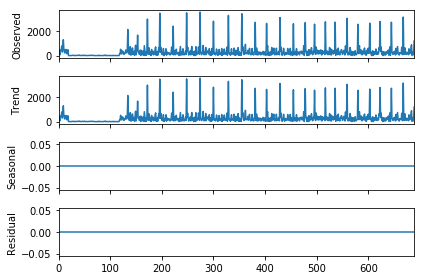

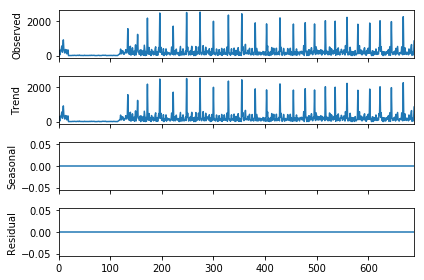

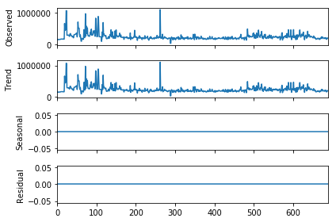

```python
from random import randrange
from pandas import Series
from matplotlib import pyplot
from statsmodels.tsa.seasonal import seasonal_decompose

result = seasonal_decompose(df['call_count_in'].dropna(), model='additive', freq=1)
result.plot()
pyplot.show()

result = seasonal_decompose(df['call_count_out'].dropna(), model='additive', freq=1)
result.plot()
pyplot.show()

result = seasonal_decompose(df['response_time_avg'].dropna(), model='additive', freq=1)
result.plot()
pyplot.show()
```

# Missing values fulfill

As explained before, with time-series data decomposed and showing only sines of Trend without Seasonality, the best option to fulfill data is to perform a linear interpolation on the data. From this, bellow is a piece of code that applies linear interpolation to the dataframe.

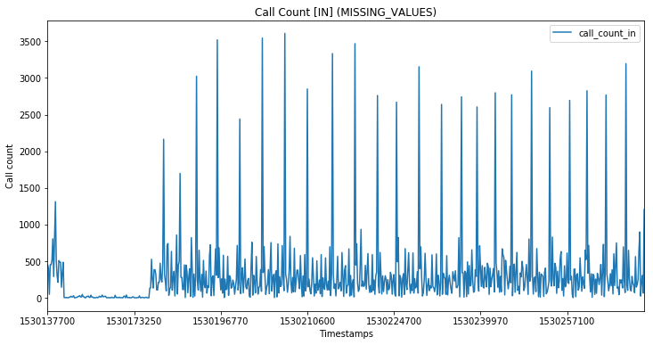

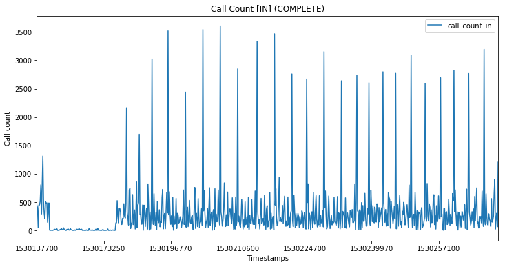

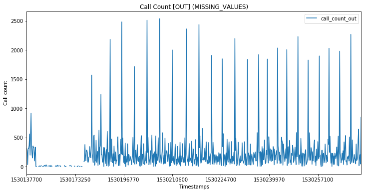

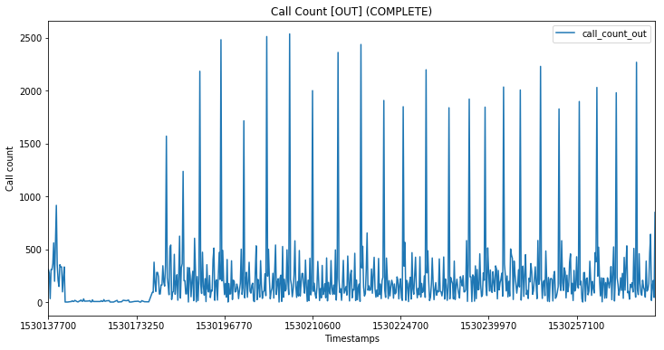

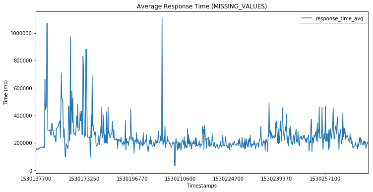

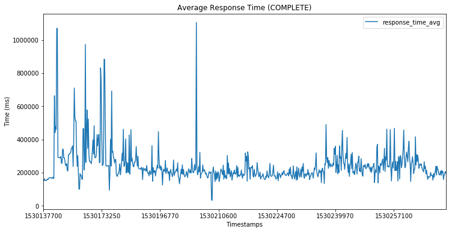

```python
df = df_copy.copy()

df = df.interpolate(method ='linear')

df_copy.plot(x='time', y='call_count_in', figsize=(12,6))
plt.xlabel('Timestamps')
plt.ylabel('Call count')
plt.title('Call Count [IN] (MISSING_VALUES)')

df.plot(x='time', y='call_count_in', figsize=(12,6))
plt.xlabel('Timestamps')
plt.ylabel('Call count')
plt.title('Call Count [IN] (COMPLETE)')

df_copy.plot(x='time', y='call_count_out', figsize=(12,6))
plt.xlabel('Timestamps')
plt.ylabel('Call count')
plt.title('Call Count [OUT] (MISSING_VALUES)')

df.plot(x='time', y='call_count_out', figsize=(12,6))
plt.xlabel('Timestamps')
plt.ylabel('Call count')
plt.title('Call Count [OUT] (COMPLETE)')

df_copy.plot(x='time', y='response_time_avg', figsize=(12,6))
plt.xlabel('Timestamps')
plt.ylabel('Time (ms)')
plt.title('Average Response Time (MISSING_VALUES)')

df.plot(x='time', y='response_time_avg', figsize=(12,6))
plt.xlabel('Timestamps')
plt.ylabel('Time (ms)')
plt.title('Average Response Time (COMPLETE)')
```

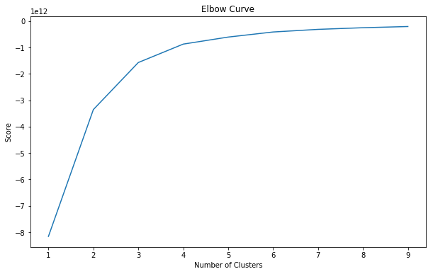

```python
from sklearn.cluster import KMeans

data = df[['call_count_in', 'call_count_in', 'response_time_avg']]
n_cluster = range(1, 10)
kmeans = [KMeans(n_clusters=i).fit(data) for i in n_cluster]
scores = [kmeans[i].score(data) for i in range(len(kmeans))]

fig, ax = plt.subplots(figsize=(10,6))
ax.plot(n_cluster, scores)
plt.xlabel('Number of Clusters')
plt.ylabel('Score')
plt.title('Elbow Curve')
plt.show();
```

[output not shown]

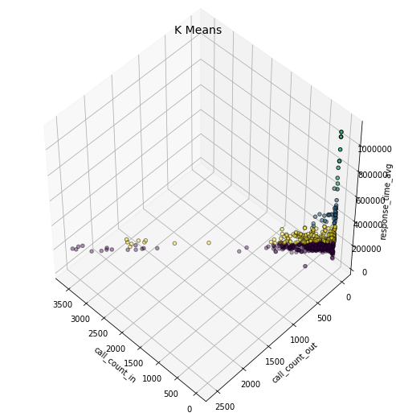

```python
import numpy as np
from mpl_toolkits.mplot3d import Axes3D

df.info()

X = df[['call_count_in', 'call_count_out', 'response_time_avg']]
X = X.reset_index(drop=True)
km = KMeans(n_clusters=4)
km.fit(X)
km.predict(X)
labels = km.labels_
#Plotting
fig = plt.figure(1, figsize=(7,7))
ax = Axes3D(fig, rect=[0, 0, 0.95, 1], elev=48, azim=134)
ax.scatter(X.iloc[:,0], X.iloc[:,1], X.iloc[:,2],
          c=labels.astype(np.float), edgecolor="k")
ax.set_xlabel("call_count_in")
ax.set_ylabel("call_count_out")
ax.set_zlabel("response_time_avg")
plt.title("K Means", fontsize=14);
```

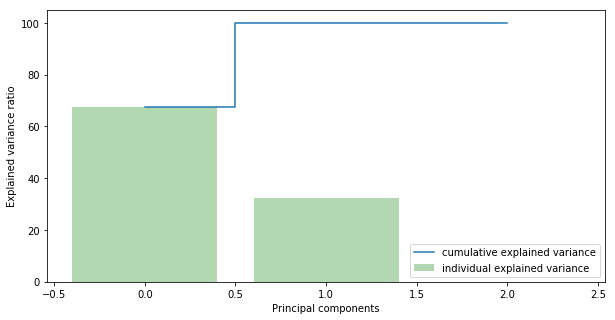

```python
from sklearn.preprocessing import StandardScaler

data = df[['call_count_in', 'call_count_out', 'response_time_avg']]
X = data.values
X_std = StandardScaler().fit_transform(X)
mean_vec = np.mean(X_std, axis=0)
cov_mat = np.cov(X_std.T)
eig_vals, eig_vecs = np.linalg.eig(cov_mat)
eig_pairs = [ (np.abs(eig_vals[i]),eig_vecs[:,i]) for i in range(len(eig_vals))]
eig_pairs.sort(key = lambda x: x[0], reverse= True)
tot = sum(eig_vals)
var_exp = [(i/tot)*100 for i in sorted(eig_vals, reverse=True)] # Individual explained variance
cum_var_exp = np.cumsum(var_exp) # Cumulative explained variance

plt.figure(figsize=(10, 5))
plt.bar(range(len(var_exp)), var_exp, alpha=0.3, align='center', label='individual explained variance', color = 'g')
plt.step(range(len(cum_var_exp)), cum_var_exp, where='mid',label='cumulative explained variance')
plt.ylabel('Explained variance ratio')
plt.xlabel('Principal components')
plt.legend(loc='best')
plt.show();
```

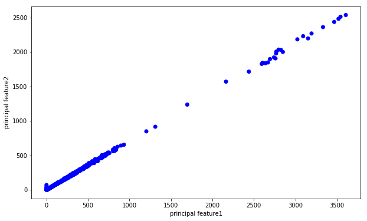

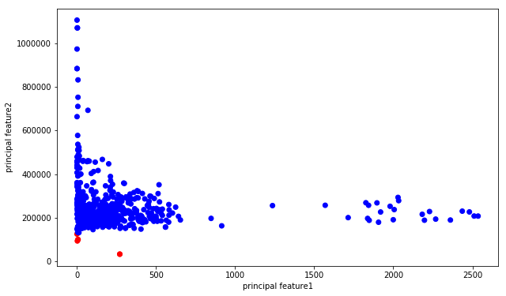

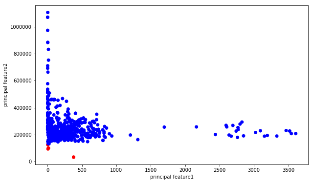

```python
def getDistanceByPoint(data, model):
    distance = pd.Series()
    for i in range(0,len(data)):
        Xa = np.array(data.loc[i])
        Xb = model.cluster_centers_[model.labels_[i]-1]
        distance.set_value(i, np.linalg.norm(Xa-Xb))
    return distance

#outliers_fraction = 0.03
outliers_fraction = 0.01
# get the distance between each point and its nearest centroid. The biggest distances are considered as anomaly
distance = getDistanceByPoint(data, kmeans[8])
number_of_outliers = int(outliers_fraction*len(distance))
threshold = distance.nlargest(number_of_outliers).min()
# anomaly contain the anomaly result of the above method Cluster (0:normal, 1:anomaly)
df['anomaly'] = (distance >= threshold).astype(int)

# visualisation of anomaly with cluster view
fig, ax = plt.subplots(figsize=(10,6))
colors = {0:'blue', 1:'red'}
ax.scatter(df['call_count_in'], df['call_count_out'], c=df["anomaly"].apply(lambda x: colors[x]))
plt.xlabel('principal feature1')
plt.ylabel('principal feature2')
plt.show();

# visualisation of anomaly with cluster view
fig, ax = plt.subplots(figsize=(10,6))
colors = {0:'blue', 1:'red'}
ax.scatter(df['call_count_out'], df['response_time_avg'], c=df["anomaly"].apply(lambda x: colors[x]))
plt.xlabel('principal feature1')
plt.ylabel('principal feature2')
plt.show();

# visualisation of anomaly with cluster view
fig, ax = plt.subplots(figsize=(10,6))
colors = {0:'blue', 1:'red'}
ax.scatter(df['call_count_in'], df['response_time_avg'], c=df["anomaly"].apply(lambda x: colors[x]))
plt.xlabel('principal feature1')
plt.ylabel('principal feature2')
plt.show();
```

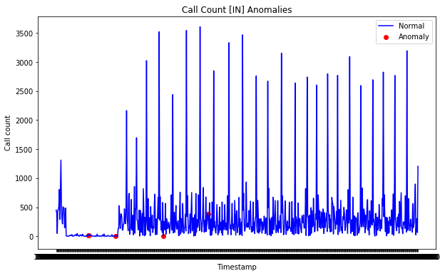

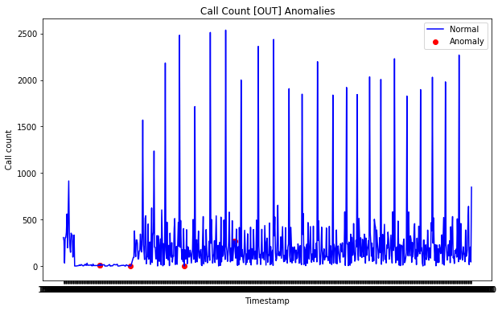

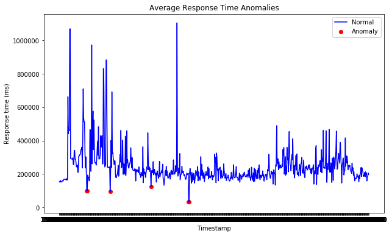

```python
df = df.sort_values('time')
fig, ax = plt.subplots(figsize=(10,6))
a = df.loc[df['anomaly'] == 1, ['time', 'call_count_in']] #anomaly

ax.plot(df['time'], df['call_count_in'], color='blue', label='Normal')
ax.scatter(a['time'],a['call_count_in'], color='red', label='Anomaly')
plt.xlabel('Timestamp')
plt.ylabel('Call count')
plt.title('Call Count [IN] Anomalies')
plt.legend()
plt.show();

fig, ax = plt.subplots(figsize=(10,6))
a = df.loc[df['anomaly'] == 1, ['time', 'call_count_out']] #anomaly

ax.plot(df['time'], df['call_count_out'], color='blue', label='Normal')
ax.scatter(a['time'],a['call_count_out'], color='red', label='Anomaly')
plt.xlabel('Timestamp')
plt.ylabel('Call count')
plt.title('Call Count [OUT] Anomalies')
plt.legend()
plt.show();

fig, ax = plt.subplots(figsize=(10,6))
a = df.loc[df['anomaly'] == 1, ['time', 'response_time_avg']] #anomaly

ax.plot(df['time'], df['response_time_avg'], color='blue', label='Normal')
ax.scatter(a['time'],a['response_time_avg'], color='red', label='Anomaly')
plt.xlabel('Timestamp')
plt.ylabel('Response time (ms)')
plt.title('Average Response Time Anomalies')
plt.legend()
plt.show();
```

```python
# Print anomalies.
df.loc[df['anomaly'] == 1]
```

|  | time | call_count_in | call_count_out | response_time_avg | anomaly |
| --- | --- | --- | --- | --- | --- |
| 61 | 1530163230 | 12 | 8.0 | 99919.250000 | 1 |
| 62 | 1530163500 | 12 | 8.0 | 99919.250000 | 1 |
| 113 | 1530176430 | 6 | 4.0 | 93554.000000 | 1 |
| 204 | 1530197250 | 3 | 2.0 | 124995.000000 | 1 |
| 288 | 1530209070 | 378 | 272.0 | 33027.949219 | 1 |
| 289 | 1530209100 | 378 | 272.0 | 33027.949219 | 1 |

### TODO: The cell bellow is not finished yet

```
            call_count_in  call_count_out  response_time_avg
time
1530137700            450      308.000000       1.524017e+05
1530138150            402      274.000000       1.513873e+05
1530138210             48       34.000000       1.616040e+05
1530138300            450      308.000000       1.524017e+05
1530138600            450      308.000000       1.524017e+05
1530140670            515      363.000000       1.517008e+05
1530140700            805      561.000000       1.571145e+05
1530140730            290      198.000000       1.613514e+05
1530141300            805      561.000000       1.571145e+05
1530142200           1312      916.000000       1.628267e+05
1530143100            507      355.000000       1.690720e+05
1530143430            296      206.000000       1.697549e+05
1530143490            211      149.000000       1.681290e+05
```

[output cut: 50 more lines]

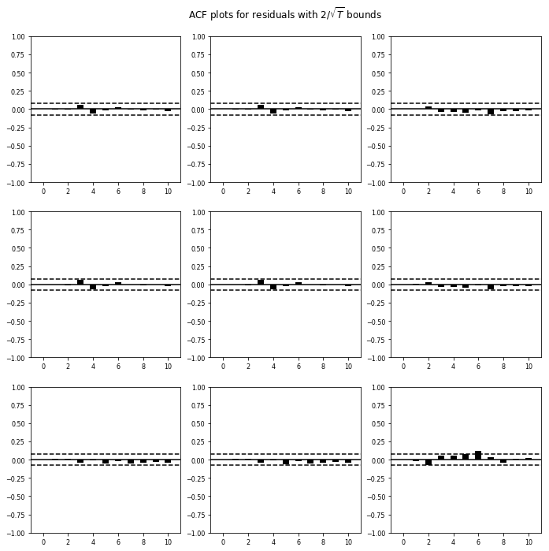

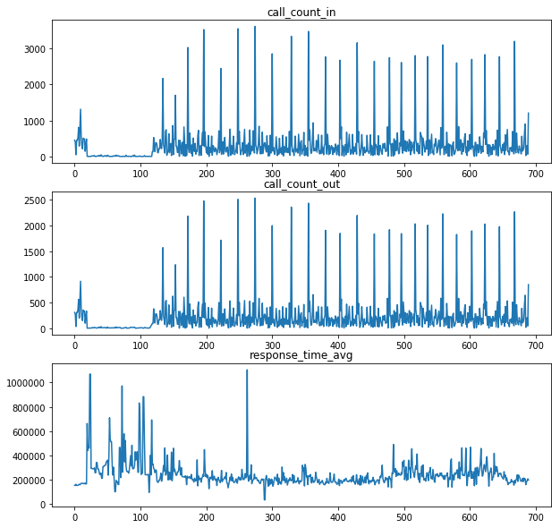

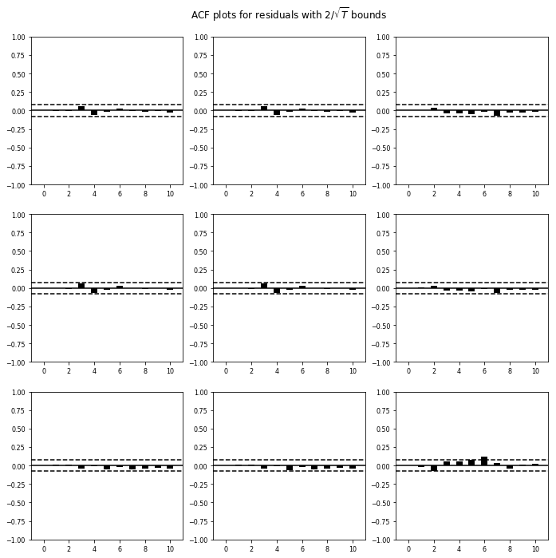

```python
import numpy
import statsmodels.api as sm

from statsmodels.tsa.api import VAR, DynamicVAR

df_new = df[['call_count_in', 'call_count_out', 'response_time_avg']]
df_new.index = df['time']
print(df_new)

data = numpy.log(df_new).diff().dropna()

model = VAR(df_new)

results = model.fit(2)

results.summary()

results.plot()

results.plot_acorr()
```

# Isolation Forests

This kind of method detects anomalies purely based on the fact that anomalies are data points that are few and different. The anomalies isolation is implemented without employing any distance or density measure. This method is fundamentally different from clustering based or distance based algorithms.

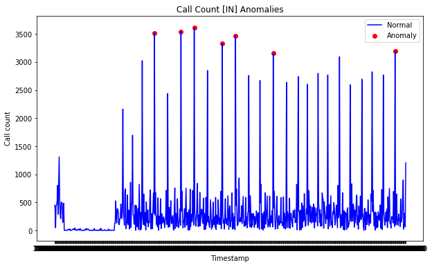

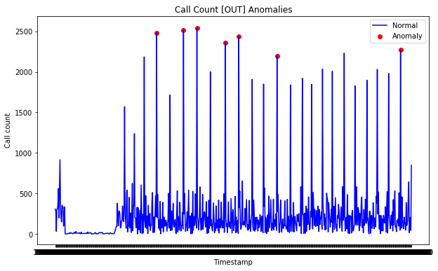

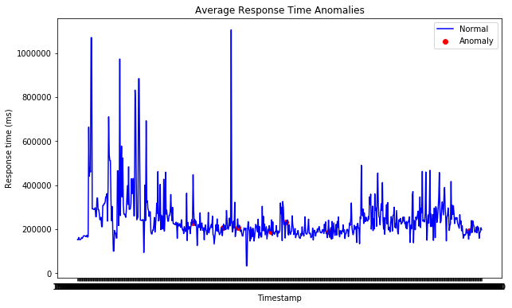

```python
from sklearn.ensemble import IsolationForest

data = df[['call_count_in', 'call_count_out', 'response_time_avg']]
scaler = StandardScaler()
np_scaled = scaler.fit_transform(data)
data = pd.DataFrame(np_scaled)
# train isolation forest
model =  IsolationForest(contamination=outliers_fraction)
model.fit(data)
df['anomaly2'] = pd.Series(model.predict(data))

fig, ax = plt.subplots(figsize=(10,6))
a = df.loc[df['anomaly2'] == -1, ['time', 'call_count_in']] #anomaly

ax.plot(df['time'], df['call_count_in'], color='blue', label='Normal')
ax.scatter(a['time'],a['call_count_in'], color='red', label='Anomaly')
plt.xlabel('Timestamp')
plt.ylabel('Call count')
plt.title('Call Count [IN] Anomalies')
plt.legend()
plt.show();

fig, ax = plt.subplots(figsize=(10,6))
a = df.loc[df['anomaly2'] == -1, ['time', 'call_count_out']] #anomaly

ax.plot(df['time'], df['call_count_out'], color='blue', label='Normal')
ax.scatter(a['time'],a['call_count_out'], color='red', label='Anomaly')
plt.xlabel('Timestamp')
plt.ylabel('Call count')
plt.title('Call Count [OUT] Anomalies')
plt.legend()
plt.show();

fig, ax = plt.subplots(figsize=(10,6))
a = df.loc[df['anomaly2'] == -1, ['time', 'response_time_avg']] #anomaly

ax.plot(df['time'], df['response_time_avg'], color='blue', label='Normal')
ax.scatter(a['time'],a['response_time_avg'], color='red', label='Anomaly')
plt.xlabel('Timestamp')
plt.ylabel('Response time (ms)')
plt.title('Average Response Time Anomalies')
plt.legend()
plt.show();
```

# SVM (Support Vector Machine - Based Anomaly Detection [OneClassSVM])

A SVM is typically associated with supervised learning, but OneClassSVM can be used to identify anomalies as an unsupervised problems that learns a decision function for anomaly detection: classifying new data as similar or different to the training set.

### OneClassSVM

According to the paper: Support Vector Method for Novelty Detection. SVMs are max-margin methods, i.e. they do not model a probability distribution. The idea of SVM for anomaly detection is to find a function that is positive for regions with high density of points, and negative for small densities.

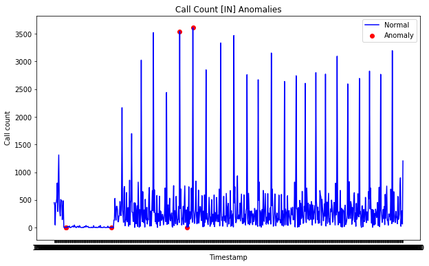

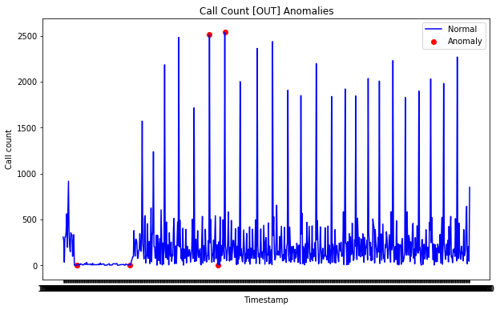

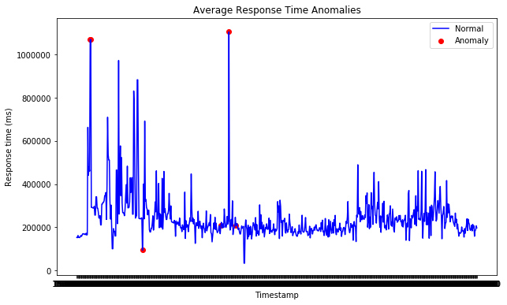

```python
from sklearn.svm import OneClassSVM

data = df[['call_count_in', 'call_count_out', 'response_time_avg']]
scaler = StandardScaler()
np_scaled = scaler.fit_transform(data)
data = pd.DataFrame(np_scaled)
# train oneclassSVM
model = OneClassSVM(nu=outliers_fraction, kernel="rbf", gamma=0.01)
model.fit(data)
df['anomaly3'] = pd.Series(model.predict(data))

fig, ax = plt.subplots(figsize=(10,6))
a = df.loc[df['anomaly3'] == -1, ['time', 'call_count_in']] #anomaly

ax.plot(df['time'], df['call_count_in'], color='blue', label='Normal')
ax.scatter(a['time'],a['call_count_in'], color='red', label='Anomaly')
plt.xlabel('Timestamp')
plt.ylabel('Call count')
plt.title('Call Count [IN] Anomalies')
plt.legend()
plt.show();

fig, ax = plt.subplots(figsize=(10,6))
a = df.loc[df['anomaly3'] == -1, ['time', 'call_count_out']] #anomaly

ax.plot(df['time'], df['call_count_out'], color='blue', label='Normal')
ax.scatter(a['time'],a['call_count_out'], color='red', label='Anomaly')
plt.xlabel('Timestamp')
plt.ylabel('Call count')
plt.title('Call Count [OUT] Anomalies')
plt.legend()
plt.show();

fig, ax = plt.subplots(figsize=(10,6))
a = df.loc[df['anomaly3'] == -1, ['time', 'response_time_avg']] #anomaly

ax.plot(df['time'], df['response_time_avg'], color='blue', label='Normal')
ax.scatter(a['time'],a['response_time_avg'], color='red', label='Anomaly')
plt.xlabel('Timestamp')
plt.ylabel('Response time (ms)')
plt.title('Average Response Time Anomalies')
plt.legend()
plt.show();
```